# 2026 Summer Institute on Longitudinal Data Analysis

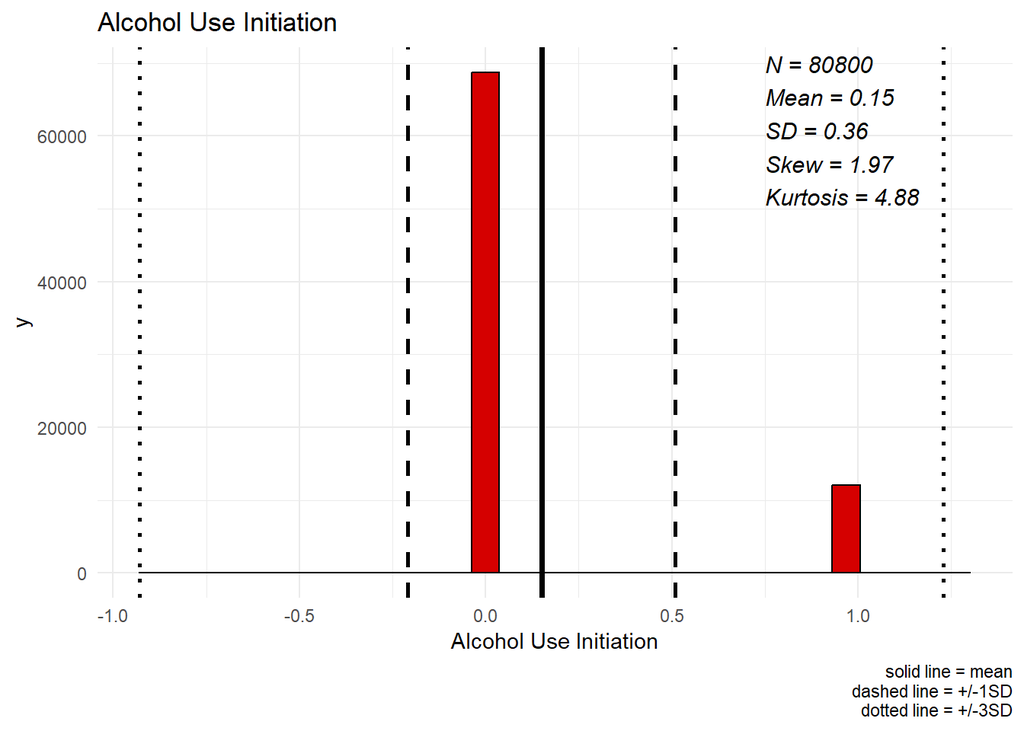

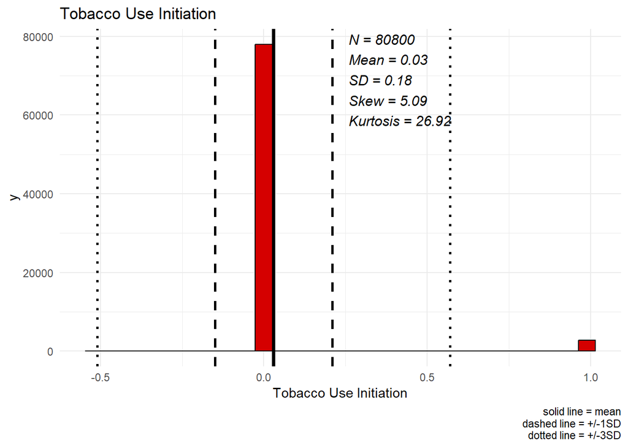

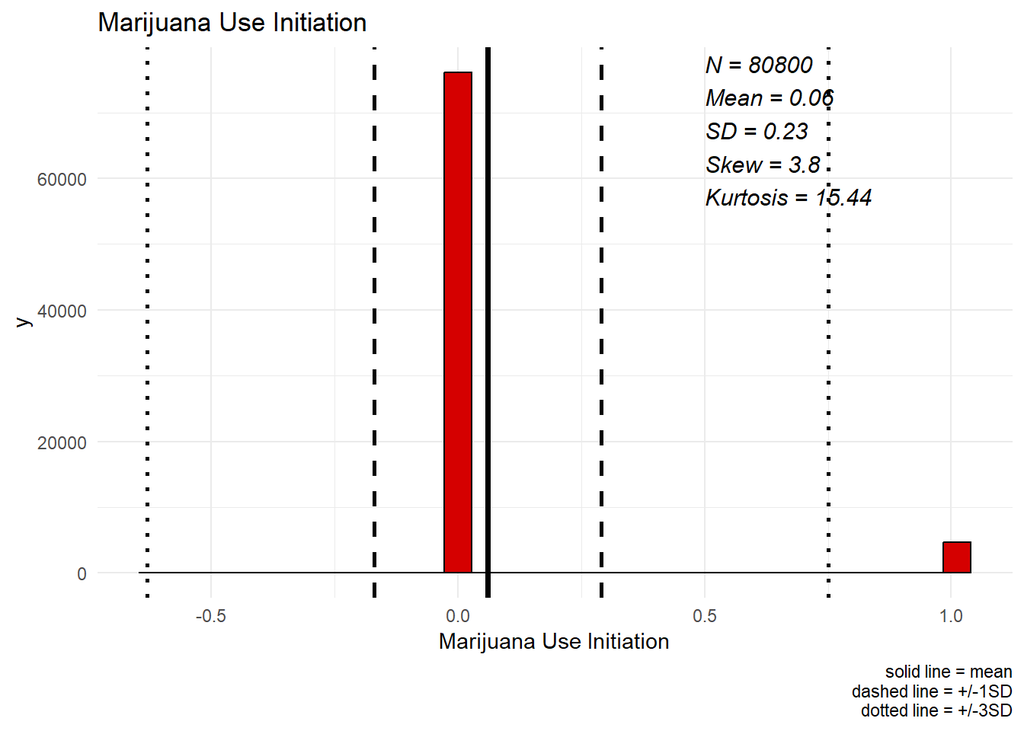

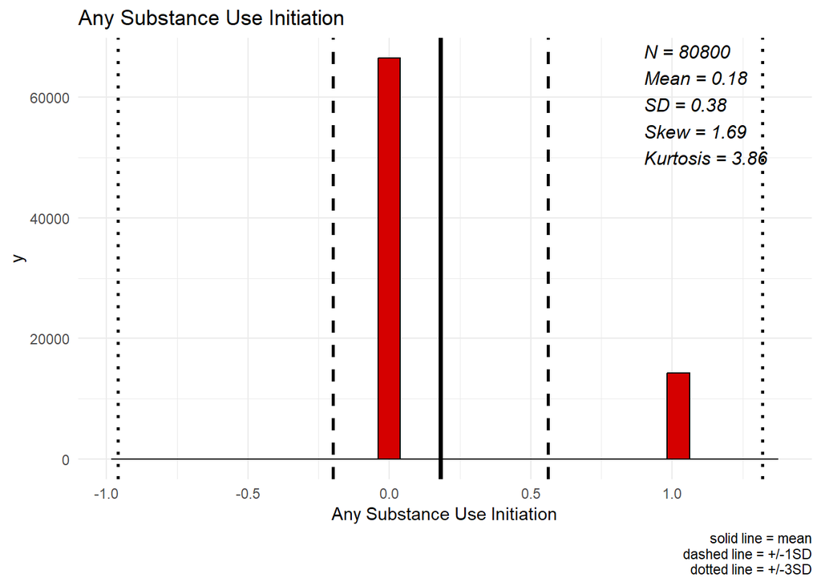

## Viz: Distributions by wave

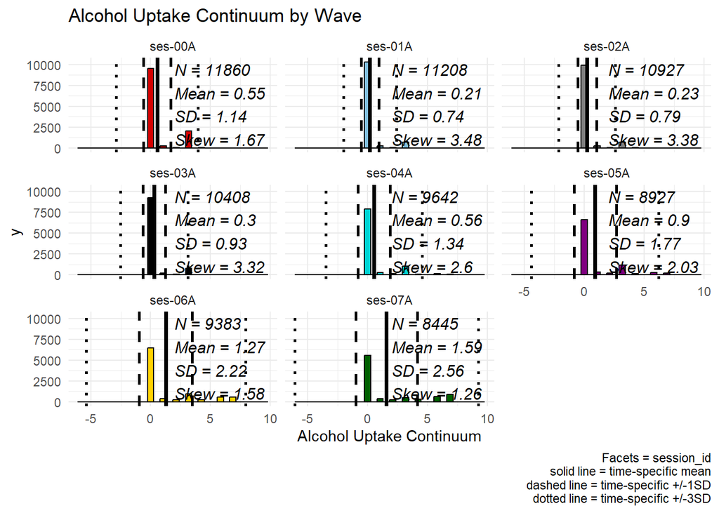

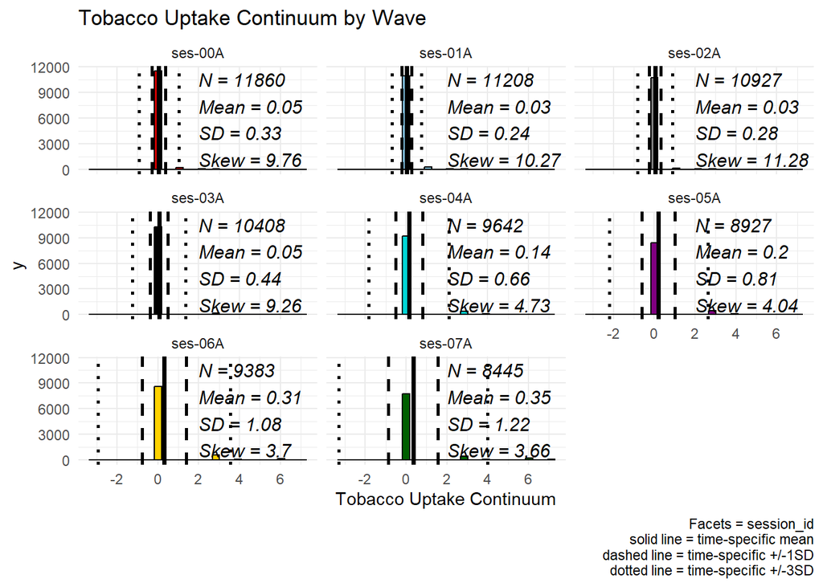

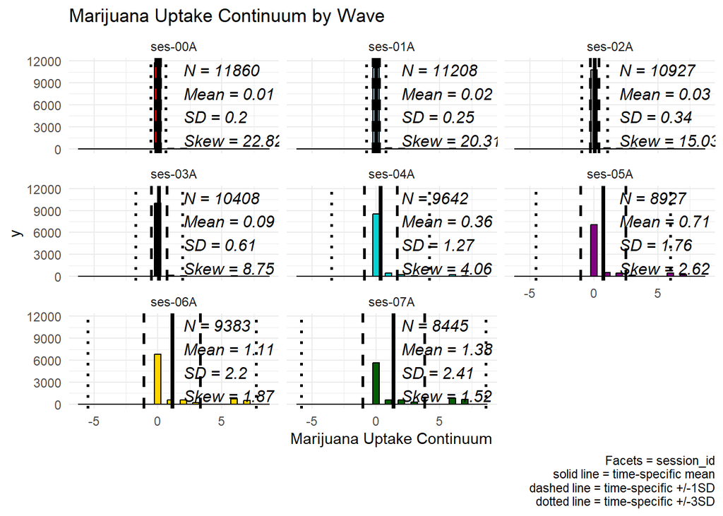

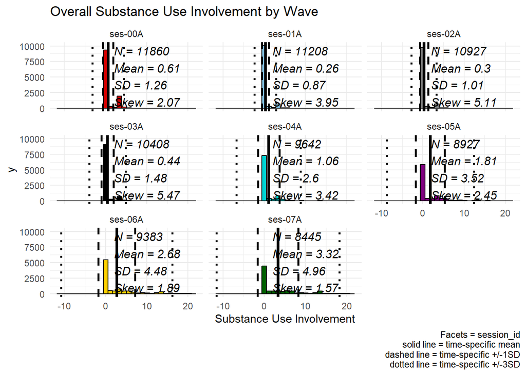

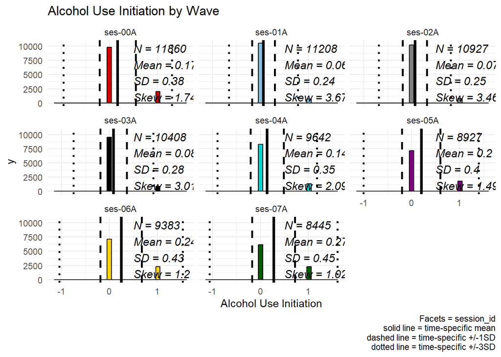

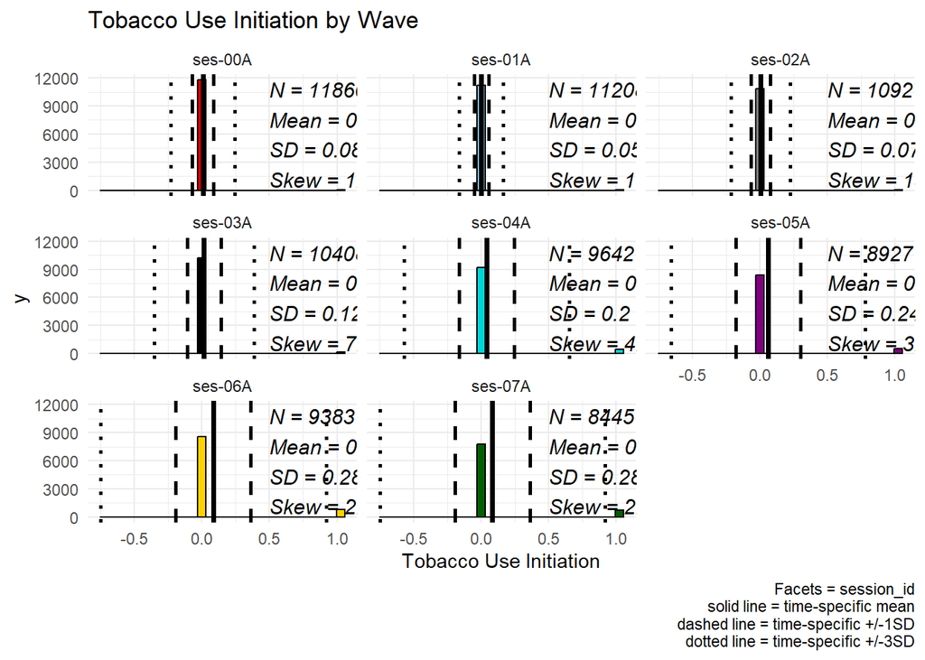

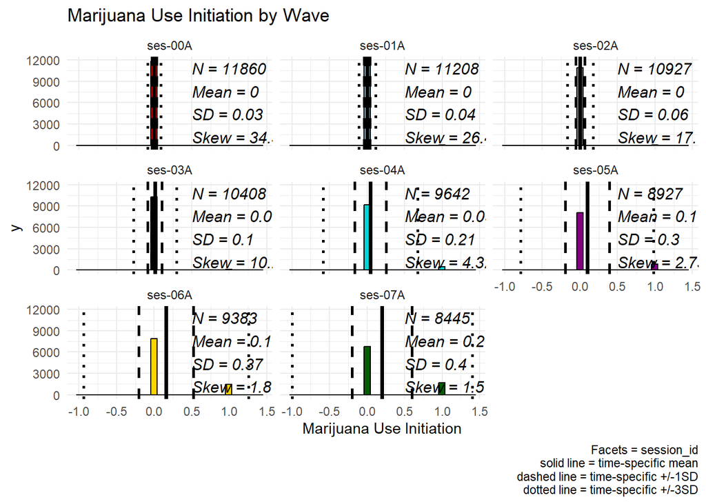

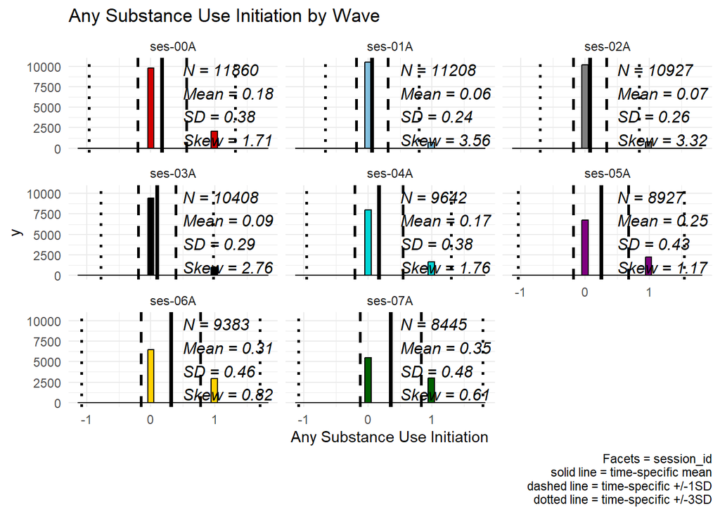

## Viz: Longitudinal Plots

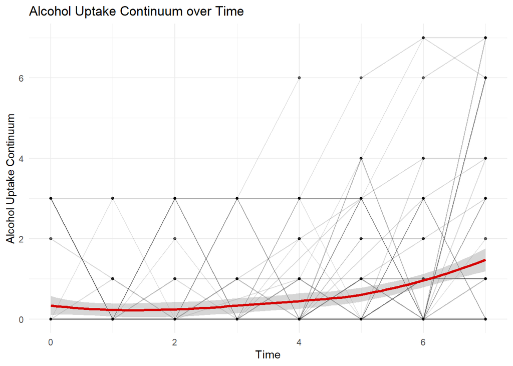

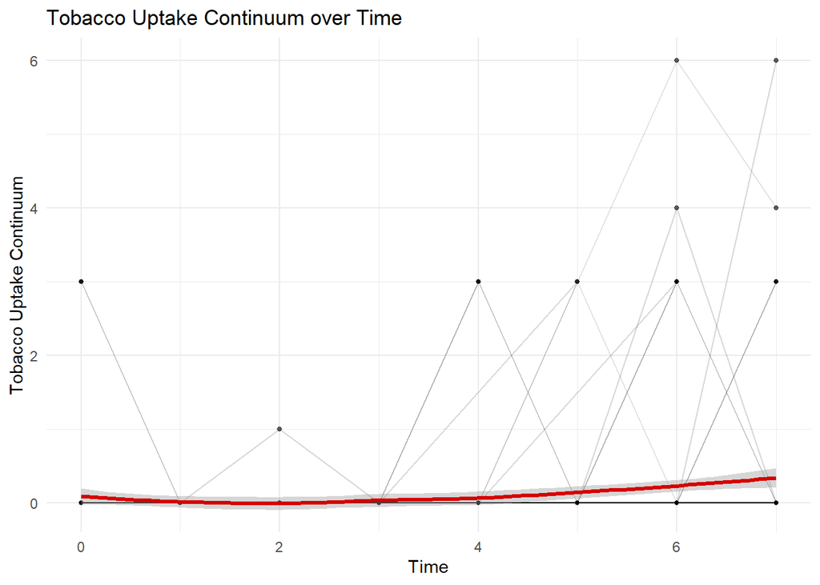

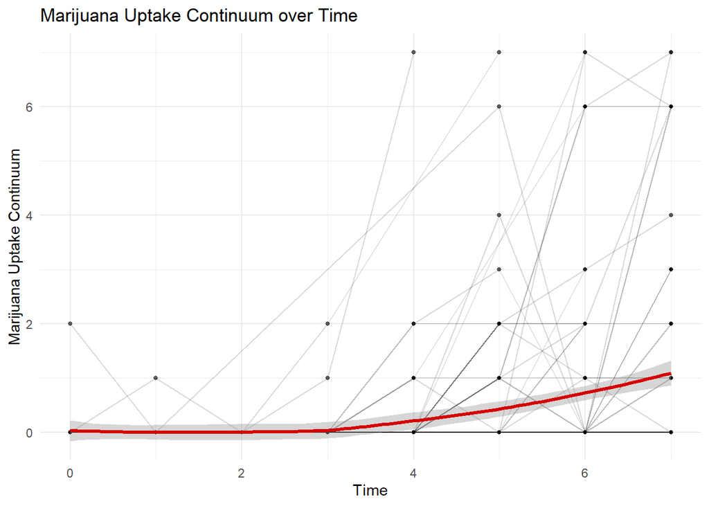

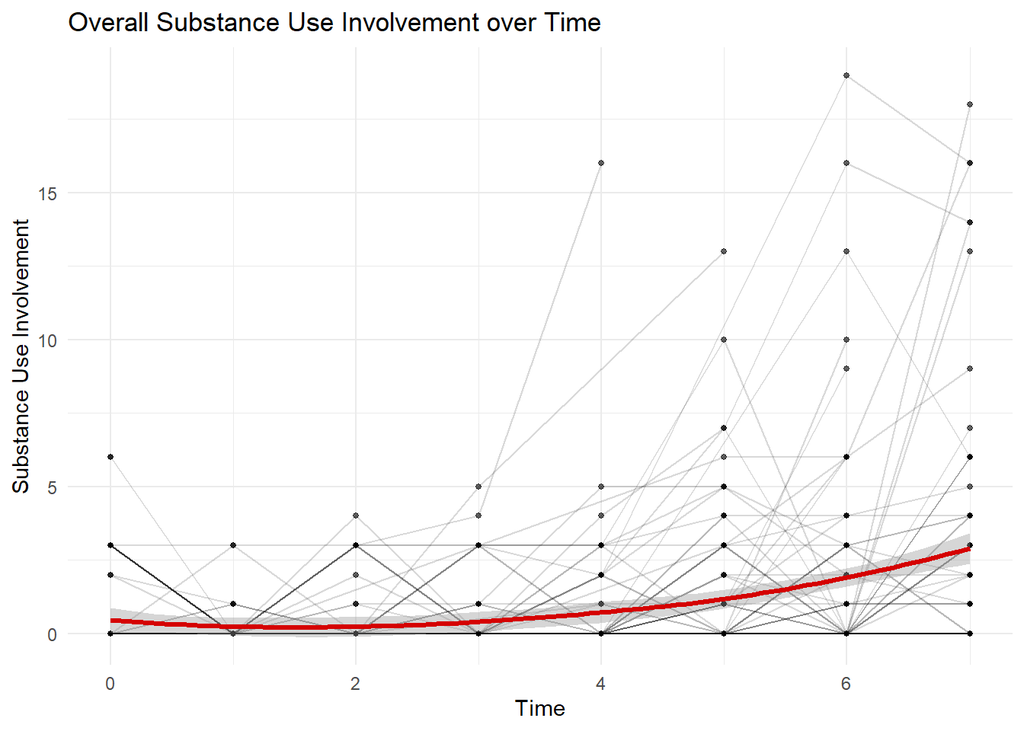

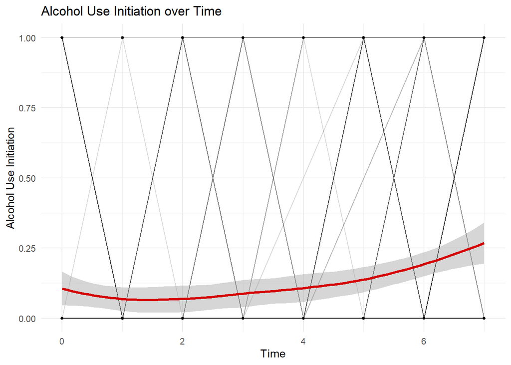

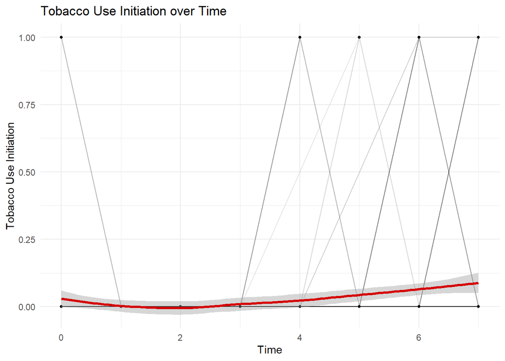

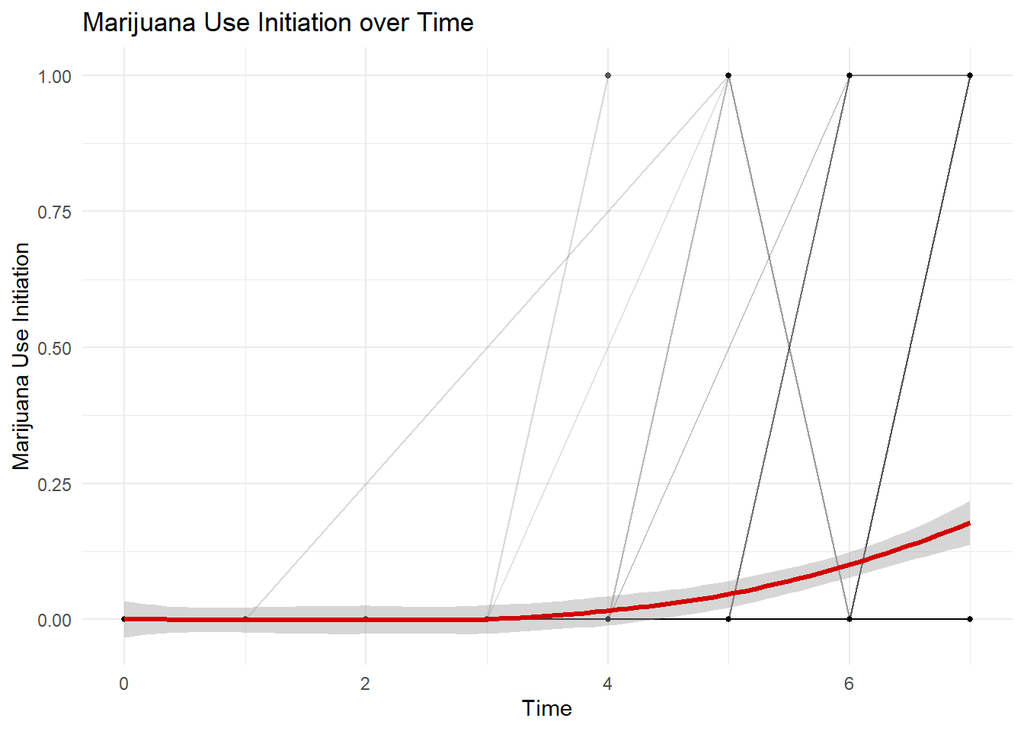

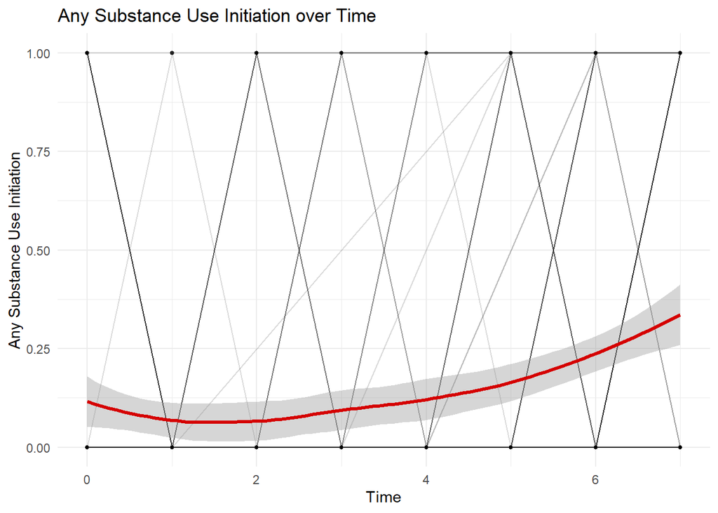

# Parent and Peer Variables

## Family Enviornment

### Datasets & Variables

**fc_y_fes**: Child-percived family cohesion and family conflict

*fc_y_fes__cohes_mean*: Family Environment Scale [Youth] (Cohesion): Mean [Validation: No more than 1 missing or declined]

*fc_y_fes__cohes_nm*: Family Environment Scale [Youth] (Cohesion): Number missing

*fc_y_fes__confl_mean*: Family Environment Scale [Youth] (Conflict): Mean [Validation: No more than 1 missing or declined]

*fc_y_fes__confl_nm*: Family Environment Scale [Youth] (Conflict): Number missing

## Peer Behavior Profile

### Datasets & Variables

**fc_y_pbp**: The Peer Behavior Profile [Youth] assesses youths’ perceptions of their friends’ behaviors and characteristics. Items were measured on an ordinal response scale: 1 = None or almost none, 2 = A few, 3 = Half, 4 = Most, 5 = All or almost all, and 999 = Don’t know. This section uses six peer behavior items. Three items reflect friends’ problem or risk behaviors, including skipping school, being suspended from school, and shoplifting. Three items reflect positive or prosocial peer characteristics, including being athletes, attending spiritual or religious services, and being excellent students. These items can be used to create negative peer and positive peer summary variables.

*fc_y_pbp_001*: How many of your friends have skipped school?

*fc_y_pbp_002*: How many of your friends have been suspended from school?

*fc_y_pbp_003*: How many of your friends have shoplifted occasionally?

*fc_y_pbp_004*: How many of your friends are athletes?

*fc_y_pbp_005*: How many of your friends attend spiritual or religious services once a month or more often?

*fc_y_pbp_006*: How many of your friends are excellent students (GPA 3.5 [B+] or higher)?

## Resistance to Peer Influence

### Datasets & Variables

**fc_y_rpi**: Child-reported Resistance to Peer Influence. The Resistance to Peer Influence [Youth] scale assesses youths’ ability to resist peer pressure and maintain autonomous decision-making in social situations. Items present paired descriptions of youth behavior, such as whether the youth tends to keep friends happy, fit in with the crowd, change their mind because of peers, or go along with what friends do. This section uses the mean summary score. Higher scores indicate greater resistance to peer influence.

*fc_y_rpi_mean*: Resistance to Peer Influence [Youth]: Mean summary score

## Parental Monitoring

### Datasets & Variables

**fc_y_pm**: Child-Perceived, General Monitoring / Knowledge

*fc_y_pm_001* (formerly parent_monitor_q1_y): “How often do your parents/guardians know where you are”. 1 = Never, 2 = Almost Never, 3 = Sometimes, 4 = Often, 5 = Always or Almost Always, 777 = Decline to answer *fc_y_pm_002* (formerly parent_monitor_q2_y): “How often do your parents know who you are with when you are not at school and away from home”. 1 = Never, 2 = Almost Never, 3 = Sometimes, 4 = Often, 5 = Always or Almost Always, 777 = Decline to answer *fc_y_pm_003* (formerly parent_monitor_q3_y): “If you are at home when parents/guardians not, how often do you know how to get in touch with them”. 1 = Never, 2 = Almost Never, 3 = Sometimes, 4 = Often, 5 = Always or Almost Always, 777 = Decline to answer *fc_y_pm_004* (formerly parent_monitor_q4_y): “How often do you talk to your parent or guardian about your plans for the coming day, such as your plans about what will happen at school or what you are going to do with friends” 1 = Never, 2 = Almost Never, 3 = Sometimes, 4 = Often, 5 = Always or Almost Always, 777 = Decline to answer *fc_y_pm_005* (formerly parent_monitor_q5_y): “In an average week, how many times do you and your parents/guardians eat dinner together”. 1 = Never, 2 = Almost Never, 3 = Sometimes, 4 = Often, 5 = Always or Almost Always, 777 = Decline to answer

*fc_y_pm_mean* is the summary score.

## Parental Control

Was indexed primarily by rules about substance use endorsed by parents. Items include rules about drinking, smoking, and marijuana use (reverse coded). A second set of items assessed whether parents enforced penalties for violating family rules about each substance. Higher scores will reflect more, enforced rules.

### Datasets & Variables

**su_p_rule**

Alcohol

*su_p_rule__alc_001* (formerly parent_rules_q1): Which statement best describes the rules for your child’s drinking in your house. 1 = My child is not allowed to drink under any circumstances; 2 = My child is allowed to drink at home but only on special occasions and under parent supervision; 3 = My child can have a drink when he/she asks for one; 4 = My child can drink at home whenever he/she wants to; 5 = I don’t set rules about my child’s drinking; 6 = I haven’t made rules yet about my child drinking; 777 = Decline to answer

*su_p_rule__alc_001__03* (formerly parent_rules_q3): Are these rules (regarding alcohol consumption) enforced? 0 = no; 1 = yes; 4 = I have not had to enforce these rules, 777 = Decline to answer

Smoking

*su_p_rule__nic__cig_001* (formerly parent_rules_q4): What are the family rules about smoking cigarettes ffor your child? 1 = Not allowed to smoke under any circumstances; 2 = Not allowed to smoke in home - no family rules outside home; 3 = Allowed to smoke in designated areas at home; 4 = Allowed to smoke anywhere; 5 = I don’t set rules about smoking cigarettes; 6 = I haven’t made rules yet about my child smoking cigarettes, 777 = Decline to answer

*su_p_rule__nic__cig_001__02* (formerly parent_rules_q6): Do you enforce penalties for violating family rules about smoking? 0 = Never; 1 = Rarely; 2 = Sometimes; 3 = Often; 4 = I have not had to enforce these rules, 777 = decline to answer

Marijuana

*su_p_rule__mj_001* (formerly parent_rules_q7): What are the family rules about using marijuana for your child? 1 = Not allowed to use marijuana under any circumstances; 2 = Not allowed to use marijuana in home - no family rules outside home; 3 = Allowed to use marijuana in home with permission; 4 = Allowed to use marijuana in home whenever he/she wants; 5 = I don’t set rules about marijuana use; 6 = I haven’t made rules yet about my child’s marijuana use, 777 = decline to answer

*su_p_rule__mj_001__02* (formerly parent_rules_q9) Do you enforce penalties for violating family rules about using marijuana? 1 = Never; 2 = Rarely; 3 = Sometimes; 4 = Often; 5 = I have not had to enforce these rules, 777 = decline to answer

## Data Cleaning and Variable Creation

```r
#Subset substance use rules dataset to variables of interest
s.surule <- c("participant_id", "session_id", "su_p_rule__alc_001", "su_p_rule__alc_001__03", "su_p_rule__nic__cig_001", "su_p_rule__nic__cig_001__02", "su_p_rule__mj_001", "su_p_rule__mj_001__02")
surule_subset <- surule[s.surule]

#Subset parental monitoring dataset to variables of interest
s.pm <- c("participant_id", "session_id", "fc_y_pm_mean")
pm_subset <- pm[s.pm]

#Subset family cohesion and conflict dataset to variables of interest
s.fes <- c("participant_id", "session_id","fc_y_fes__cohes_mean","fc_y_fes__confl_mean")
fes_subset <- fes[s.fes]

#Subset peer behavior dataset to variables of interest
s.pbp <- c("participant_id","session_id","fc_y_pbp_001","fc_y_pbp_002","fc_y_pbp_003","fc_y_pbp_004","fc_y_pbp_005","fc_y_pbp_006")
pbp_subset <- pbp[s.pbp]
pbp_subset <- pbp_subset %>%
  mutate(across(c(fc_y_pbp_001,fc_y_pbp_002,fc_y_pbp_003,fc_y_pbp_004,fc_y_pbp_005,fc_y_pbp_006),~ ifelse(.x == 999, NA, as.numeric(.x)))
  ) %>%
  mutate(negative_peer_mean = rowMeans(across(c(fc_y_pbp_001, fc_y_pbp_002, fc_y_pbp_003)),na.rm = TRUE),positive_peer_mean = rowMeans(across(c(fc_y_pbp_004, fc_y_pbp_005, fc_y_pbp_006)),na.rm = TRUE),negative_peer_mean = ifelse(is.nan(negative_peer_mean), NA, negative_peer_mean),positive_peer_mean = ifelse(is.nan(positive_peer_mean), NA, positive_peer_mean))
pbp_subset <- pbp_subset %>%
  select(participant_id, session_id,negative_peer_mean,positive_peer_mean)

#Subset resistance to peer influence dataset to variables of interest
s.rpi <- c("participant_id", "session_id","fc_y_rpi_mean")
rpi_subset <- rpi[s.rpi]

#pm_subset and surule_subset are measured on the annual assessments. However, sdev_subset is a substudy offered at times that may or may not correspond to the annual assessment.
#Merge pm and surule together for data cleaning and variable creation and add cleaned sdev later.
parent_peer_datavars <- list(pm_subset, surule_subset, fes_subset, pbp_subset, rpi_subset)
parmon <- Reduce(function(x, y) merge(x, y, by = c("participant_id", "session_id"), all = TRUE), parent_peer_datavars)

#The parental monitoring and substance use rules variables are factors, not numeric, which will mess up zscores later. Recode as numeric
parmon$su_p_rule__alc_001__03n <- as.numeric(as.character(parmon$su_p_rule__alc_001__03))
parmon$su_p_rule__alc_001n <- as.numeric(as.character(parmon$su_p_rule__alc_001))
parmon$su_p_rule__nic__cig_001__02n <- as.numeric(as.character(parmon$su_p_rule__nic__cig_001__02))
parmon$su_p_rule__nic__cig_001n <- as.numeric(as.character(parmon$su_p_rule__nic__cig_001))
parmon$su_p_rule__mj_001__02n <- as.numeric(as.character(parmon$su_p_rule__mj_001__02))
parmon$su_p_rule__mj_001n <- as.numeric(as.character(parmon$su_p_rule__mj_001))

#recode parent substance use rules so that 4 = I have not had to enforce these rules is 0 and so yes= 3 to match tobacco and marijuana.
#alcohol
parmon  <- parmon  %>%
  mutate(alcrulesenforce = case_when(
    (su_p_rule__alc_001__03n == 0 | su_p_rule__alc_001__03n ==4) ~ 0,
    (su_p_rule__alc_001__03n == 1) ~ 3,
    TRUE ~ NA))

#reverse code substance use rules so that higher numbers indicate stricter rules.
parmon  <- parmon  %>%
  mutate(alcrules = case_when(
    (su_p_rule__alc_001n == 5 | su_p_rule__alc_001n == 6) ~ 0,
    (su_p_rule__alc_001n == 4) ~ 1,
    (su_p_rule__alc_001n == 3) ~ 2,
    (su_p_rule__alc_001n == 2) ~ 3,
    (su_p_rule__alc_001n == 1) ~ 4,
    TRUE ~ NA))

#tobacco
parmon  <- parmon  %>%
  mutate(tobrulesenforce = case_when(
    (su_p_rule__nic__cig_001__02n == 0 | su_p_rule__nic__cig_001__02n == 4) ~ 0,
    (su_p_rule__nic__cig_001__02n == 1) ~ 1,
    (su_p_rule__nic__cig_001__02n == 2) ~ 2,
    (su_p_rule__nic__cig_001__02n == 3) ~ 3,
    TRUE ~ NA))

#reverse code substance use rules so that higher numbers indicate stricter rules.
parmon  <- parmon  %>%
  mutate(tobrules = case_when(
    (su_p_rule__nic__cig_001n == 6 | su_p_rule__nic__cig_001n ==5 ) ~ 0,
    (su_p_rule__nic__cig_001n == 4) ~ 1,
    (su_p_rule__nic__cig_001n == 3) ~ 2,
    (su_p_rule__nic__cig_001n == 2) ~ 3,
    (su_p_rule__nic__cig_001n == 1) ~ 4,
    TRUE ~ NA))

#marijuana
parmon  <- parmon  %>%
  mutate(mjrulesenforce = case_when(
    (su_p_rule__mj_001__02n == 1 | su_p_rule__mj_001__02n ==5) ~ 0,
    (su_p_rule__mj_001__02n == 2) ~ 1,
    (su_p_rule__mj_001__02n == 3) ~ 2,
    (su_p_rule__mj_001__02n == 4) ~ 3,
    TRUE ~ NA))

#reverse code substance use rules so that higher numbers indicate stricter rules.
parmon  <- parmon %>%
  mutate(mjrules = case_when(
    (su_p_rule__mj_001 == 6 | su_p_rule__mj_001 ==5 ) ~ 0,
    (su_p_rule__mj_001 == 4) ~ 1,
    (su_p_rule__mj_001 == 3) ~ 2,
    (su_p_rule__mj_001 == 2) ~ 3,
    (su_p_rule__mj_001 == 1) ~ 4,
    TRUE ~ NA))

#Standardize variables prior to subscale creation
#create formula to generate z-scores
calculate_z <- function(X, X_mean, S){
  return((X-X_mean)/S)
}

parmon <- parmon %>%
  rename(ch_gen_know = fc_y_pm_mean)

#Child Perceived General Monitoring / Knowledge
parmon <- parmon %>% group_by(session_id) %>%
  mutate(zch_gen_know = calculate_z(ch_gen_know,
      mean(ch_gen_know, na.rm = TRUE),
      sd(ch_gen_know, na.rm = TRUE)))

##Parental Control Variables
parmon <- parmon  %>% group_by(session_id) %>%
  mutate(zsurq1 = calculate_z(alcrules,
      mean(alcrules, na.rm = TRUE),
      sd(alcrules, na.rm = TRUE)))

parmon <- parmon  %>% group_by(session_id) %>%
  mutate(zsurq3 = calculate_z(alcrulesenforce,
      mean(alcrulesenforce, na.rm = TRUE),
      sd(alcrulesenforce, na.rm = TRUE)))

parmon  <- parmon  %>% group_by(session_id) %>%
  mutate(zsurq4 = calculate_z(tobrules,
      mean(tobrules, na.rm = TRUE),
      sd(tobrules, na.rm = TRUE)))

parmon  <- parmon  %>% group_by(session_id) %>%
  mutate(zsurq6 = calculate_z(tobrulesenforce,
      mean(tobrulesenforce, na.rm = TRUE),
      sd(tobrulesenforce, na.rm = TRUE)))

parmon <- parmon %>% group_by(session_id) %>%
  mutate(zsurq7 = calculate_z(mjrules,
      mean(mjrules, na.rm = TRUE),
      sd(mjrules, na.rm = TRUE)))

parmon  <- parmon  %>% group_by(session_id) %>%
  mutate(zsurq9 = calculate_z(mjrulesenforce,
      mean(mjrulesenforce, na.rm = TRUE),
      sd(mjrulesenforce, na.rm = TRUE)))

parmon <- parmon %>% rowwise() %>%
    mutate(par_su_rules= mean(c(zsurq1, zsurq3, zsurq4, zsurq6, zsurq7, zsurq9), na.rm=TRUE))

#pairdown to just outcome variables
s.pm <- c("participant_id", "session_id", "ch_gen_know", "par_su_rules", "fc_y_fes__cohes_mean", "fc_y_fes__confl_mean", "negative_peer_mean", "positive_peer_mean", "fc_y_rpi_mean")

parmon <- parmon[s.pm]

#Note: Final data frame name parmon
```

## Viz: Distributions across all waves

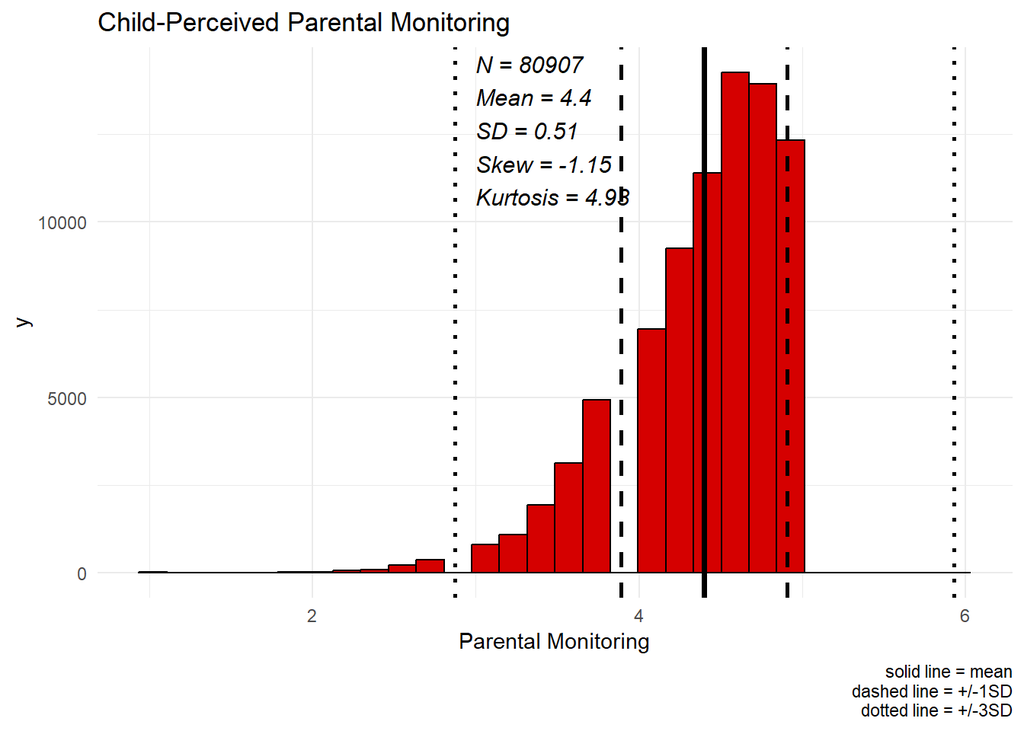

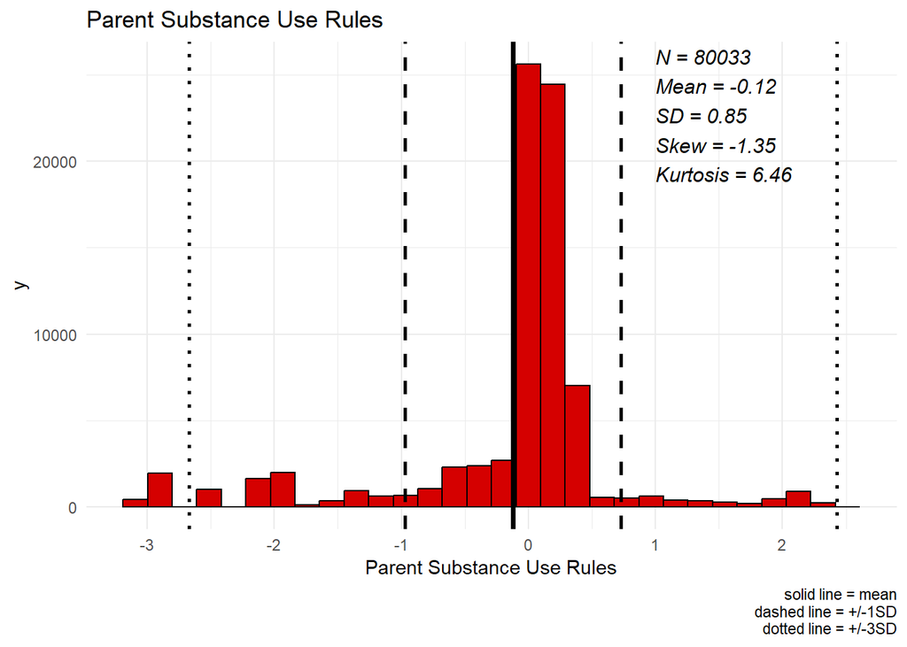

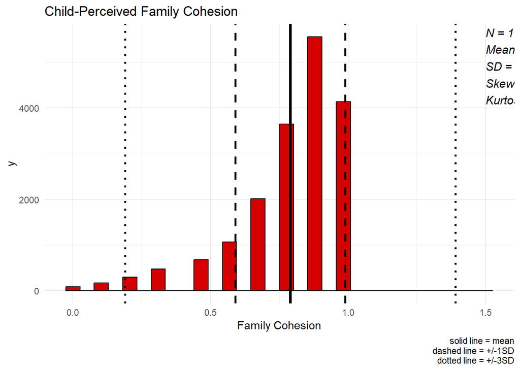

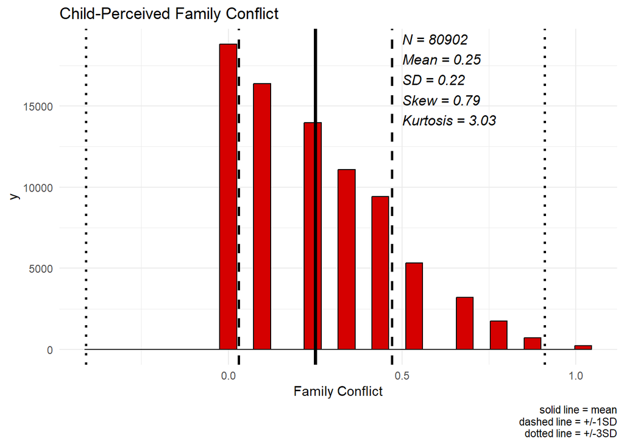

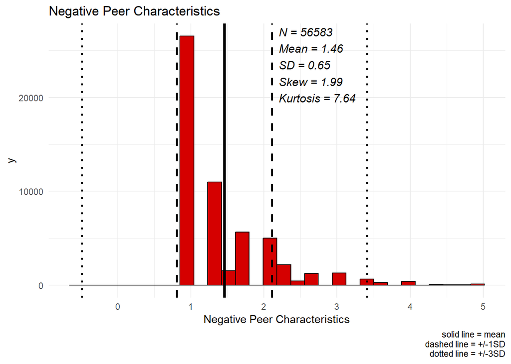

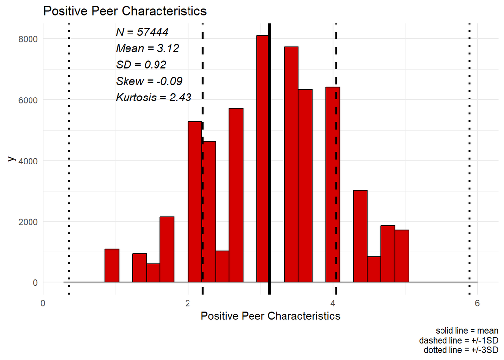

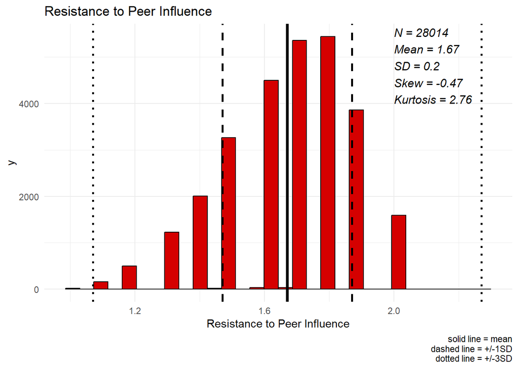

## Viz: Distributions by wave

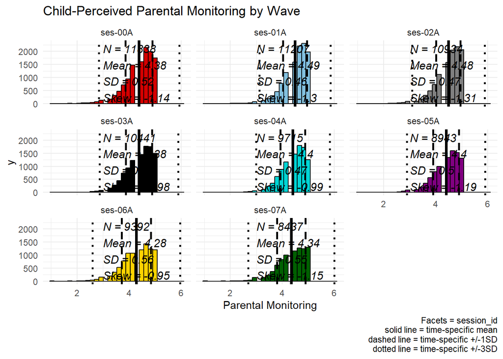

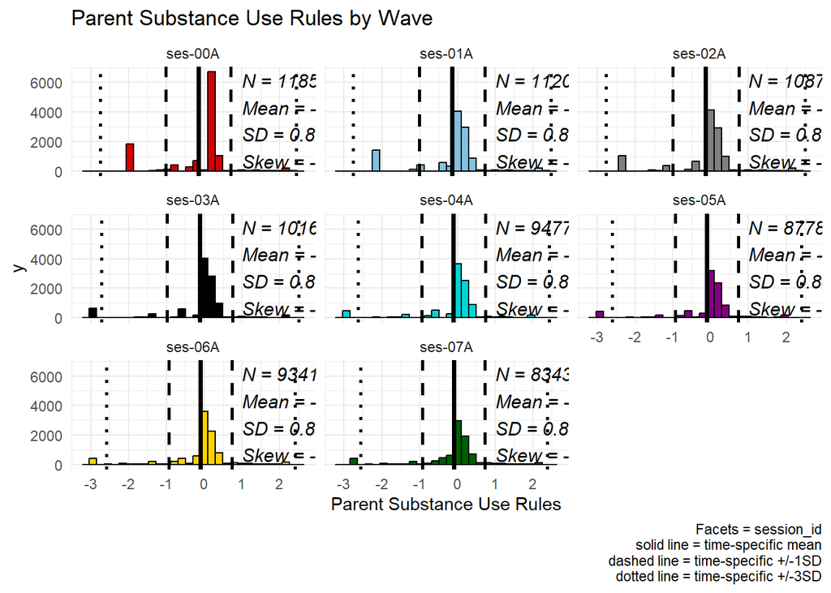

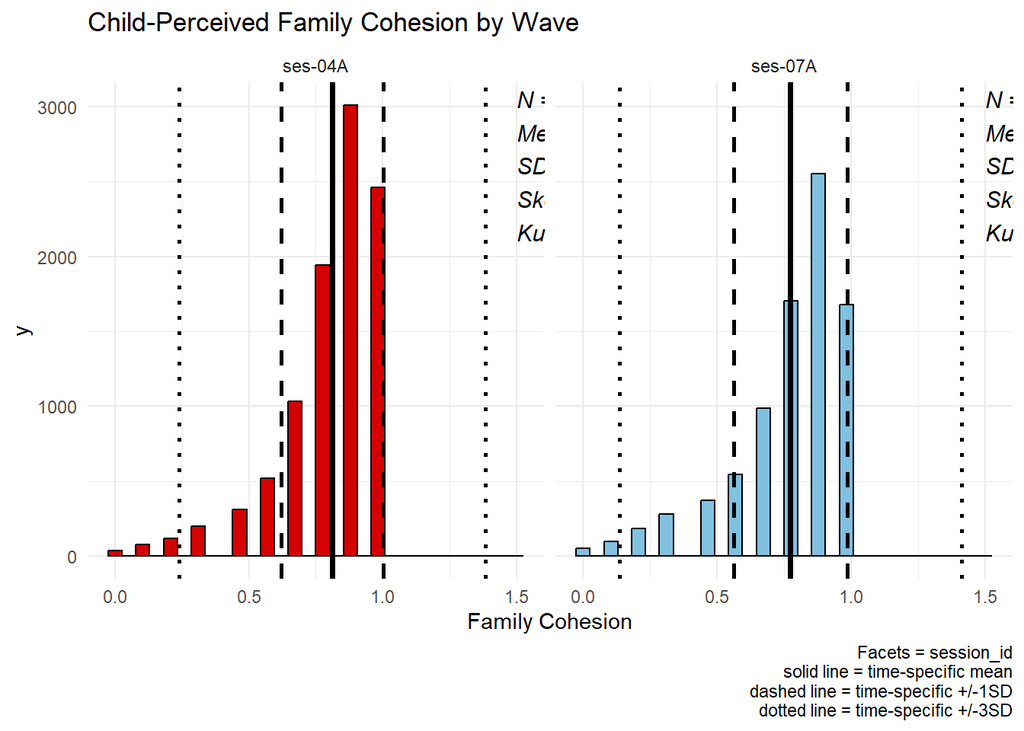

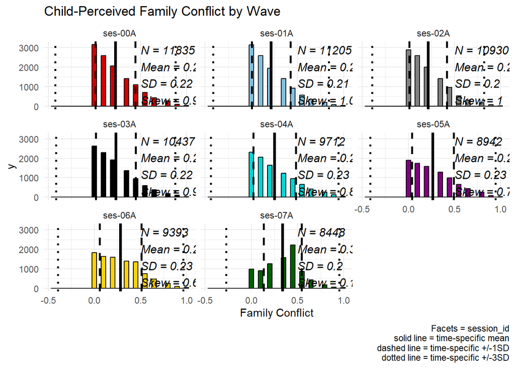

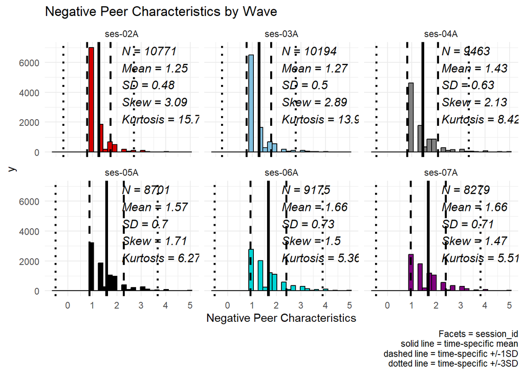

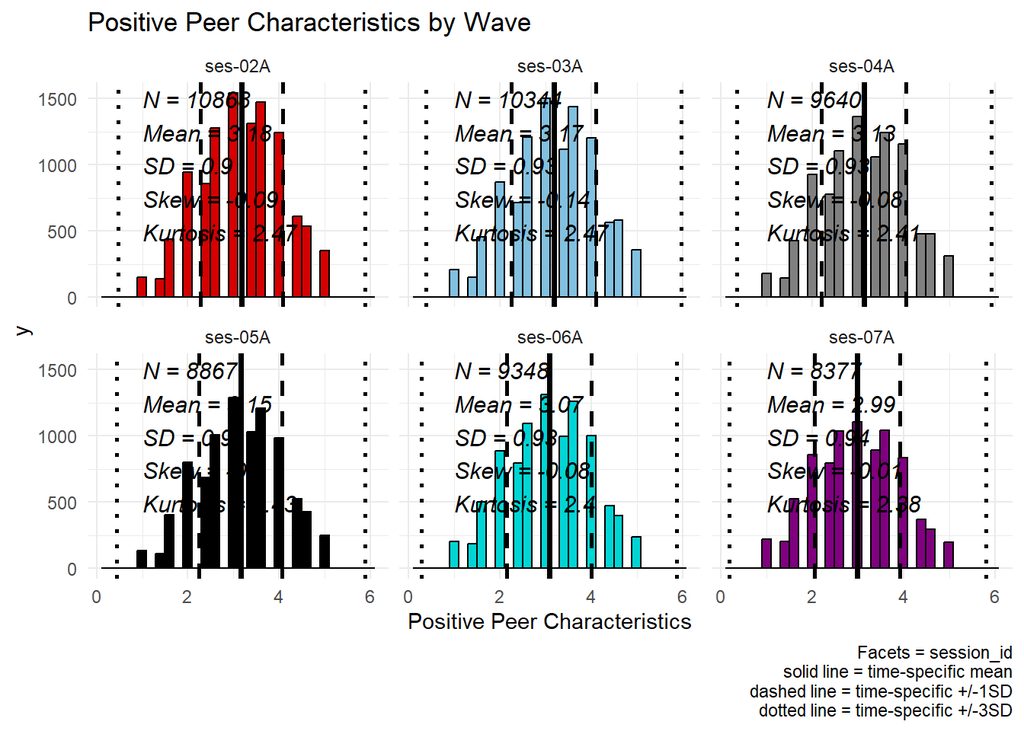

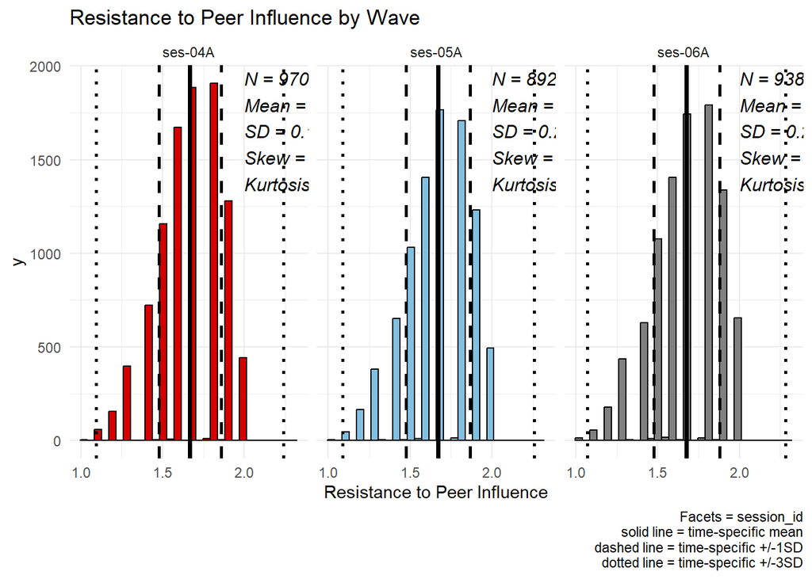

## Viz: Longitudinal Plots

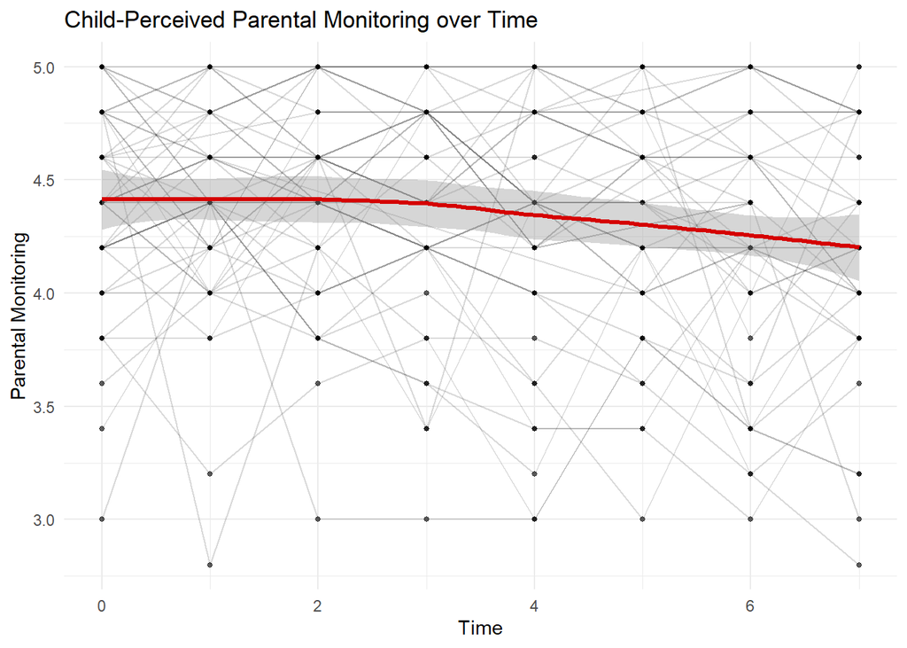

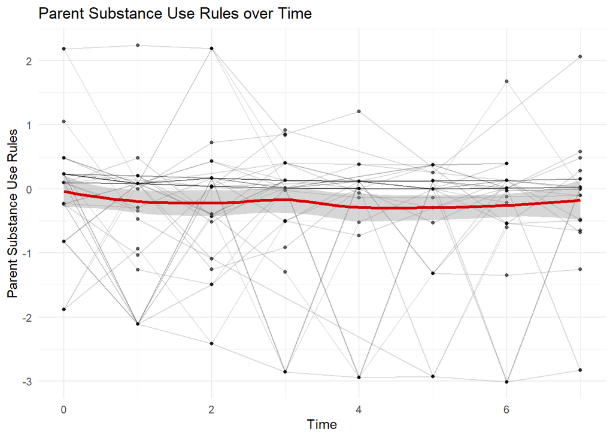

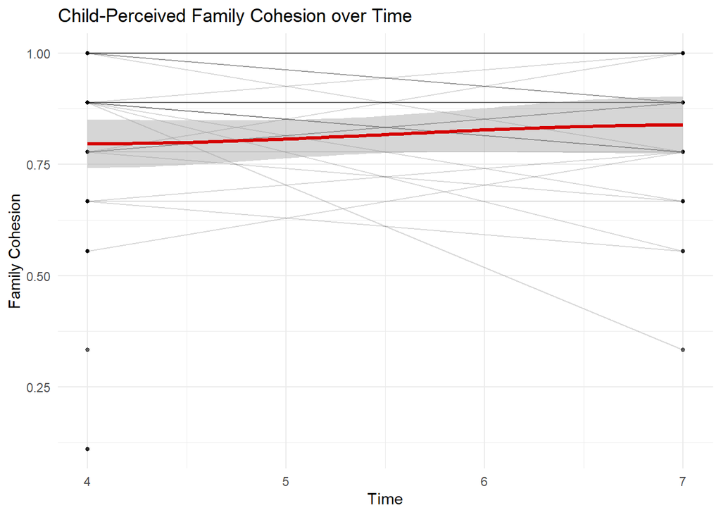

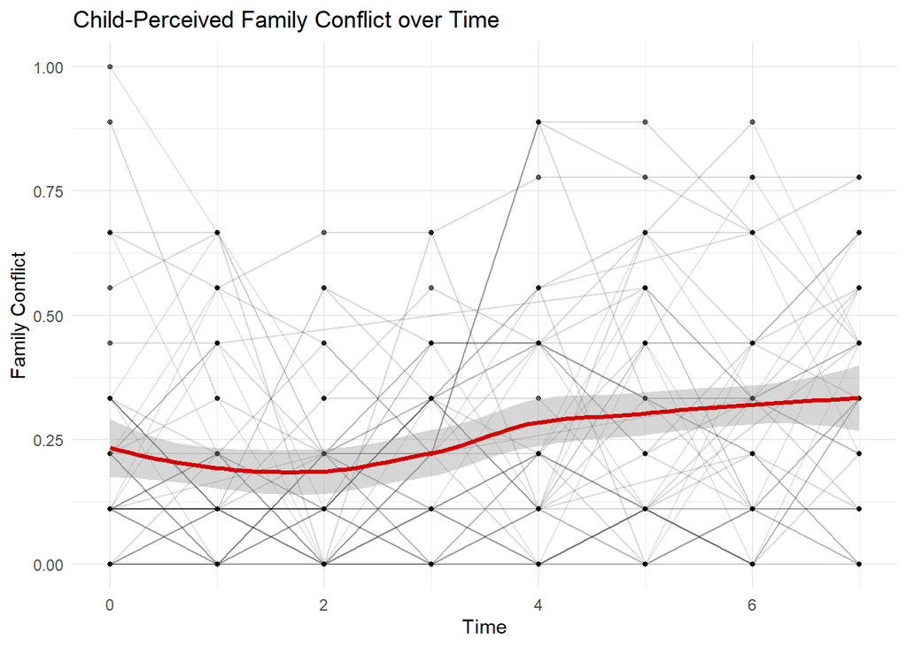

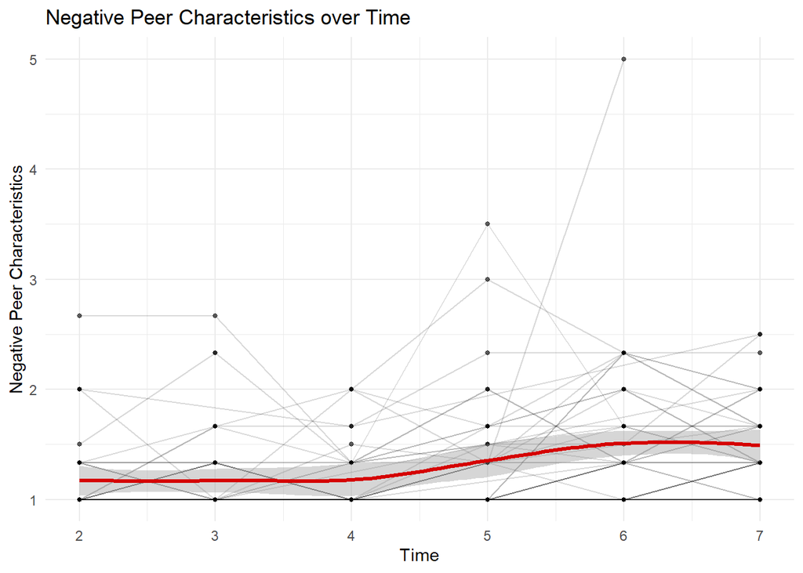

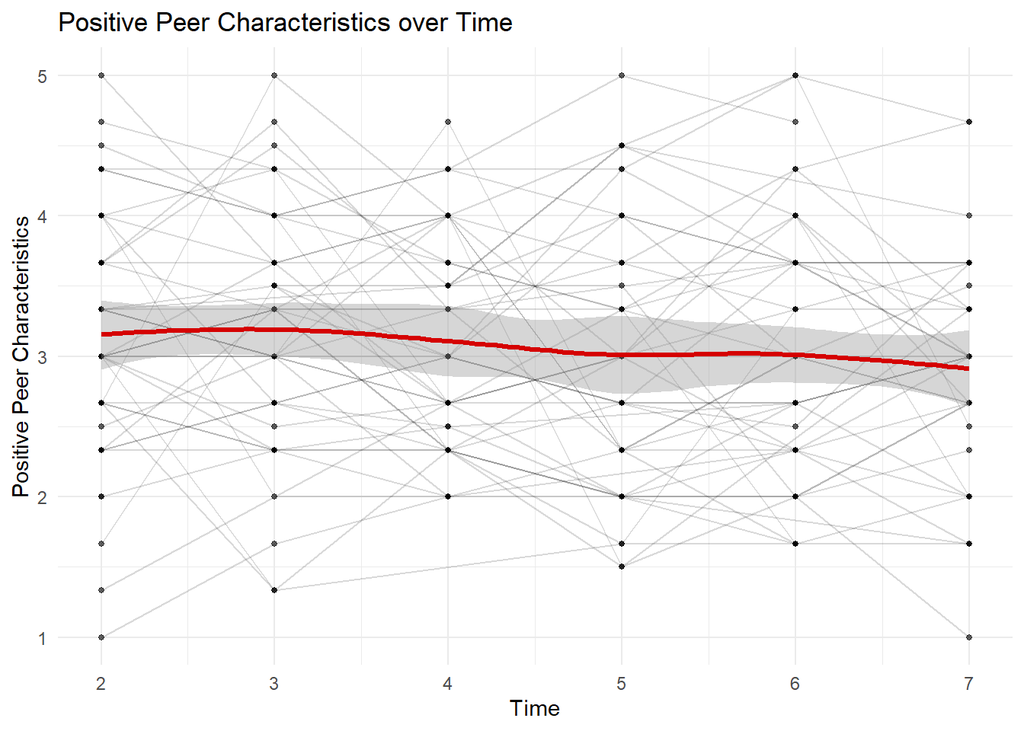

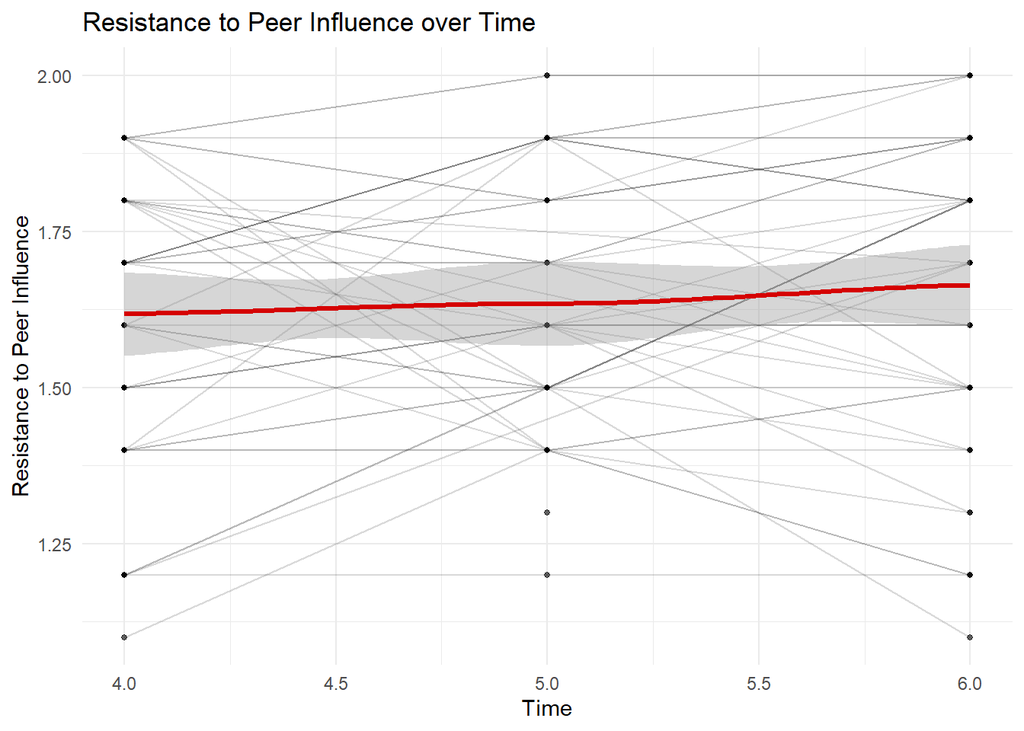

# Linked External Data

## Dataset(s) & Variables

**le_l_adi**: Area Deprivation Index; a neighborhood-level composite measure of socioeconomic disadvantage. Higher values indicate greater neighborhood deprivation. variables were measured at baseline (00A).

*le_l_adi__addr1__income_med*: Median family income [Area Deprivation Index] (Address 1)

*le_l_adi__addr1__mortgage_med*: Median monthly mortgage [Area Deprivation Index] (Address 1)

**le_l_svi**: Social Vulnerability Index; a neighborhood-level composite measure of community vulnerability based on social, economic, demographic, and housing-related factors. Higher values indicate greater social vulnerability. variables were measured at baseline (00A)

*le_l_svi__addr1__17younger_prcnt*: Percent population estimate of persons 17 and younger subcomponent [CDC SVI (ACS 2014-2018 5 yr avg); census tract] (Address 1)

**le_l_densalc**: Alcohol outlet density based on Census 2016 measures; captures the density of alcohol outlets in the participant’s residential area. Higher values indicate greater alcohol outlet density. variables were measured at baseline (00A)

*le_l_densalc__addr1__alc_density__2016*: Estimate of alcohol outlet density (Number of Establishments where alcohol could be purchased and/or consumed based on North American Industry Classification System (NAICS) from ZIP Code Business Patterns from Census 2016) (Address 1)

## Data Cleaning & Variable Creation

```r
#Subset brief adi/svi/densalc to variables of interest
s.adi <- c("participant_id", "session_id","le_l_adi__addr1__income_med", "le_l_adi__addr1__mortgage_med")
adi_subset <- adi[s.adi]

s.svi <- c("participant_id", "session_id","le_l_svi__addr1__17younger_prcnt")
svi_subset <- svi[s.svi]

s.densalc <- c( "participant_id", "session_id","le_l_densalc__addr1__alc_density__2016")
densalc_subset <- densalc[s.densalc]

le <- adi_subset %>%
  full_join(svi_subset, by = c("participant_id", "session_id")) %>%
  full_join(densalc_subset, by = c("participant_id", "session_id"))

# Final data frame name le
```

## Viz: Distributions of linked external data at baseline

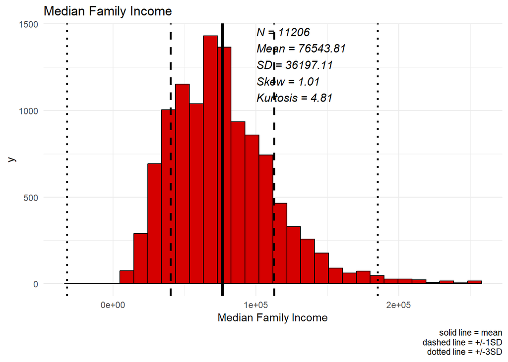

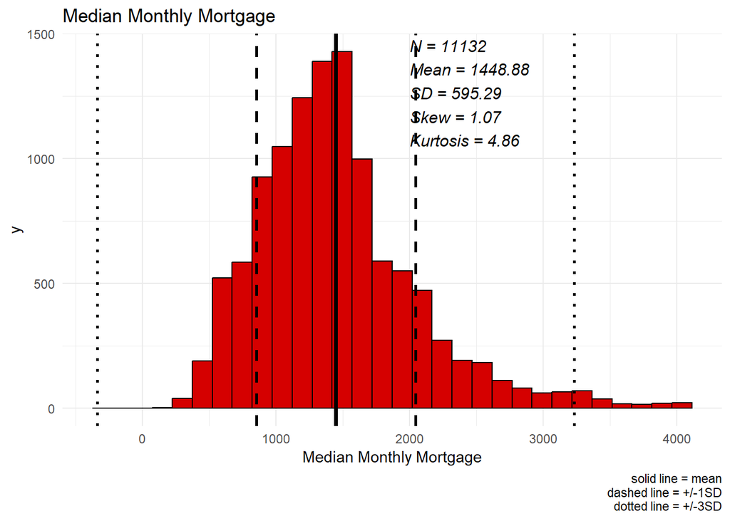

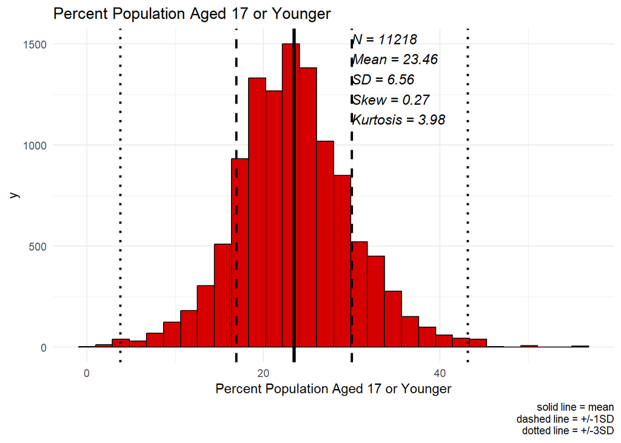

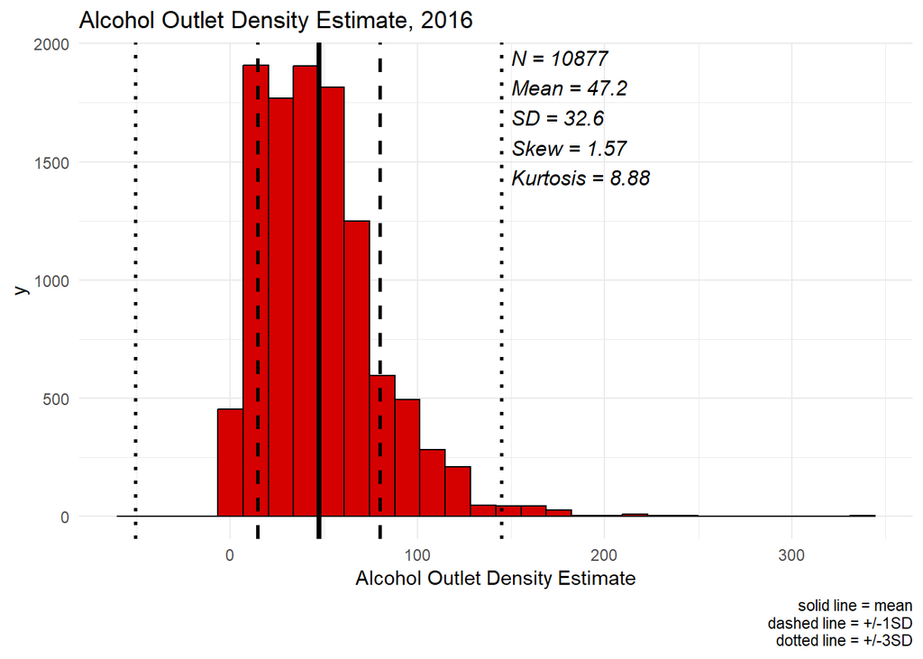